# SparCC (global gut full data)

Back to Table of Contents

**All of the code in this page is meant to be run on the command line unless otherwise specified.**

## Install SparCC

Download the repository from the [downloads page](https://bitbucket.org/yonatanf/sparcc/downloads). Unzip the folder, and put it somewhere convenient (like in your course code repository folder). Test that it is working by running the following command on the command line:

```bash
# Test that SparCC is running.
# Note that you will have to fix the path to be the correct path
# to the "SparCC.py" file on your computer.
python ../../../sparcc/SparCC.py -h
```

```
## Usage: Compute the correlation between components (e.g. OTUs).
## By default uses the SparCC algorithm to account for compositional effects.
## Correlation and covariance (when applies) matrices are written out as txt files.
## Counts file needs to be a tab delimited text file where columns are samples and rows are components (e.g. OTUS).
##  See example/fake_data.txt for an example file.
##
## Usage:   python SparCC.py counts_file [options]
## Example: python SparCC.py example/fake_data.txt -i 20 --cor_file=Cor_mat.out
##
## Options:
##   -h, --help            show this help message and exit
##   -c COR_FILE, --cor_file=COR_FILE
##                         File to which correlation matrix will be written.
##   -v COV_FILE, --cov_file=COV_FILE
##                         File to which covariance matrix will be written.
##   -a ALGO, --algo=ALGO  Name of algorithm used to compute correlations (SparCC
##                         (default) | pearson | spearman | kendall)
##   -i ITER, --iter=ITER  Number of inference iterations to average over (20
##                         default).
##   -x XITER, --xiter=XITER
##                         Number of exclusion iterations to remove strongly
##                         correlated pairs (10 default).
##   -t TH, --thershold=TH
##                         Correlation strength exclusion threshold (0.1
##                         default).
```

## Prepare data

We will run SparCC on the Global Gut genus data, only including adults living in the USA. We will also choose a subset of the more prevalent genera (present in about 20% of people or more) for testing to keep things running quickly.

```bash
# RUN ON THE COMMAND LINE

# First, extract only adults living in the USA.
filter_samples_from_otu_table.py -i otu_table.biom -m map.txt -o otu_table_USA_adults.biom -s "AGE_GROUP:ADULT;COUNTRY:GAZ:United States of America" --output_mapping_fp map_USA_adults.txt

# Summarize taxa at the genus level
summarize_taxa.py -i otu_table_USA_adults.biom -L 6 -o taxa-USA-adults

# remove genera present in < 60 samples
filter_otus_from_otu_table.py -i taxa-USA-adults/otu_table_USA_adults_L6.biom -s 60 -o taxa-USA-adults/otu_table_USA_adults_L6_s60.biom

# create a text version (for SparCC) and a JSON version (for R)
biom convert -i taxa-USA-adults/otu_table_USA_adults_L6_s60.biom --to-json -o taxa-USA-adults/otu_table_USA_adults_L6_s60_json.biom
biom convert -i taxa-USA-adults/otu_table_USA_adults_L6_s60.biom --to-tsv -o taxa-USA-adults/otu_table_USA_adults_L6_s60.txt

# Now remove the first line of the taxon file. Same would apply to an OTU table.
sed 1d taxa-USA-adults/otu_table_USA_adults_L6_s60.txt > taxa-USA-adults/otu_table_USA_adults_L6_s60_for_sparcc.txt
```

## Run SparCC

```bash
python ../../../sparcc/SparCC.py taxa-USA-adults/otu_table_USA_adults_L6_s60_for_sparcc.txt
```

```
## reading data
## computing correlations
##  Running iteration 0
##  Running iteration 1
##  Running iteration 2
##  Running iteration 3
##  Running iteration 4
##  Running iteration 5
##  Running iteration 6
##  Running iteration 7
##  Running iteration 8
##  Running iteration 9
##  Running iteration 10
##  Running iteration 11
##  Running iteration 12
##  Running iteration 13
##  Running iteration 14
##  Running iteration 15
##  Running iteration 16
##  Running iteration 17
##  Running iteration 18
##  Running iteration 19
## writing results
## wrote cor_mat_SparCC.out
## wrote cov_mat_SparCC.out
## Done!
```

The correlation output will be in the file cor_mat_SparCC.out.

## Comparison to Spearman correlation

Now we will compare SparCC to Spearman correlation in R.

**The following commands will be run in R.**

First, load the data into **R**.

```r
# load the biom library
library('biom')
# read in the biom table and extract the data
x <- t(as.matrix(biom_data(read_biom('taxa-USA-adults/otu_table_USA_adults_L6_s60_json.biom'))))

# read in the sparcc results
sparcc.mat <- read.table('cor_mat_SparCC.out',sep='\t',head=T,row=1)
```

Plot a histogram of correlations inferred by Spearman correlation.

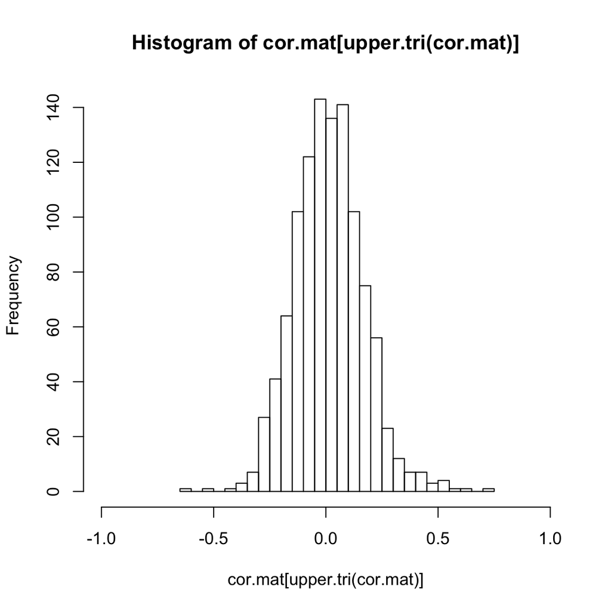

```r
cor.mat <- cor(x,method='spear')
hist(cor.mat[upper.tri(cor.mat)], br=30, xlim=c(-1,1))
```

There are a number of large correlations found above 0.5. Let us compare to SparCC.

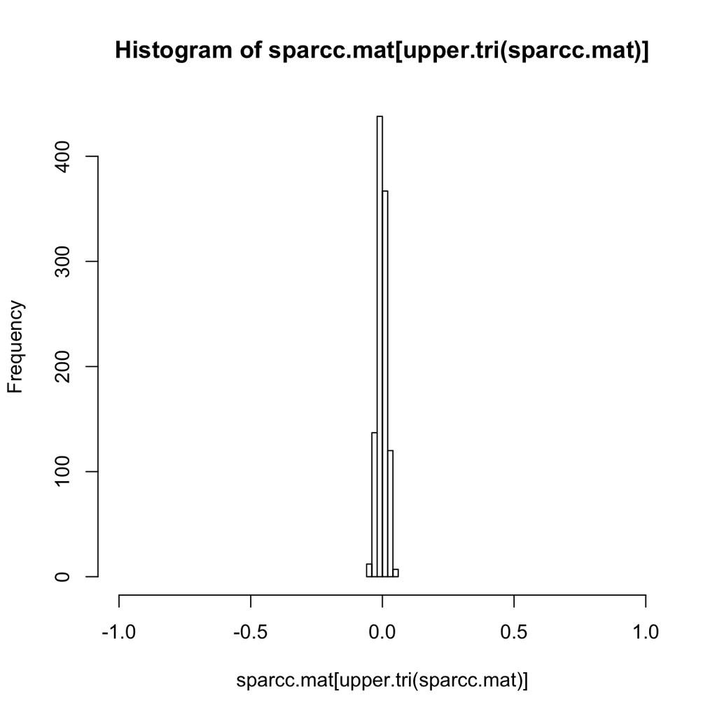

```r
hist(sparcc.mat[upper.tri(sparcc.mat)],br=6,xlim=c(-1,1))
```

SparCC found no large correlations, indicating that the correlations found by Spearman correlation could be explained by compositional artifacts.